# Lab 1 Key - Intro to R/RStudio, RProj, and a few wrangling basics

Allison Horst

# Lab 1 objectives

By the end of Lab 1, you should be able to…

- Create a new .Rproj and add files to working directory
- Attach packages with library()
- Read in a CSV with readr::read_csv()
- Explore data a little bit
- Do some basic wrangling with dplyr (`select()`, `filter()`, `mutate()`, `group_by()`, `summarize()`)
- Use the pipe operator (`%>%`)
- Create basic graphs with `ggplot2`

**Setup:** Make a directory (folder) on our computer that you’ll put all of your ESM 206 labs in. Maybe Documents > Bren courses > esm_206 > labs

# Part 1: Hello, RStudio

# Part 2: Hello, RMarkdown

Create a new RMarkdown document. You can save this directly in your labs folder.

Some basics of RMarkdown:

- Bulleted lists
- With a dash then a space to start the line
- Make sure to have a blank line before it.
  - You can have nested lists
1. Numbered lists
2. Also work

Create different header levels:

# Largest (single pound sign)

### Get smaller as you add more pound signs

##### Even smaller with more pound signs…

*Italics* with a single asterisk on each end **Bold** with a double asterisk on each end

Or, check out the visual editor!!!

Knitting: create an html from your .Rmd.

# Part 3: Hello, data

## Create a new R project and add data

In RStudio:

- Create a new R project (blue cube) - save in the labs folder you created above
- Download the mack_creek_verts.csv file from GauchoSpace
- Copy and paste the mack_creek_verts.csv file into the project folder
- Within the R project, create a new R Markdown document, deleting everything below the setup code chunk
- Attach the `tidyverse`, `janitor` and `here` packages (if you don’t have janitor and here installed, run `install.packages("janitor")` and `install.packages("here")` in the Console)

**Data citation:** Gregory, S.V. and I. Arismendi. 2020. Aquatic Vertebrate Population Study in Mack Creek, Andrews Experimental Forest, 1987 to present ver 14. Environmental Data Initiative. https://doi.org/10.6073/pasta/7c78d662e847cdbe33584add8f809165

**Metadata:** For information on the Mack Creek Vertebrates data, see metadata [HERE](https://portal.edirepository.org/nis/metadataviewer?packageid=knb-lter-and.4027.14).

## Read in Mack Creek Vertebrates data

In a new code chunk, use `read_csv()` to read in the mack_creek_verts.csv data as a new stored object ‘verts’ (**note:** your file path will differ from this! Make sure you use the right path within YOUR project). We use `here()` to point to different files *within our project*.

```r
verts <- read_csv(here("esm206-f2021-lab1", "mack_creek_verts.csv"))
```

Make sure to **run** that code, and note that `verts` now appears in the Environment tab. Click on the name of the object in the Environment to run the View() function, which will bring up `verts` in its own tab to take a look.

## Do some basic exploring

Let’s take a look at the data we just read in. We’ll do this in the Console, because we don’t care about having a history of this initial exploration.

- `head()`: Return the first 6 lines
- `tail()`: Return the last 6 lines
- `names()`: Return the column headers
- `summary()`: Basic summary of columns

## Clean up column names with janitor::clean_names()

The column names are not particularly coder-friendly (all caps - annoying to work with). There are a number of ways to update column headers, but `janitor::clean_names()` is a really great one that will update them all to lower_snake_case all at once!

We will also use the pipe operator (`%>%`), which is imported when we attach the tidyverse, for the first time. We can think of the pipe as a way to say “and then…” between sequential bits of code. It allows us to perform sequences of steps in a logical way, instead of using a bunch of nested functions!

The shortcut to add the pipe is Command + Shift + M.

The code below creates a new object, verts_clean, that starts from verts *and then* applies janitor::clean_names()!

```r
verts_clean <- verts %>% clean_names()
```

Run the code, then look at the outcome `verts_clean` to ensure that the column headers are updated.

## Basic wrangling

We’ve already done a lot in this session: created a project, dropped data into the project folder, read in data, cleaned column names, and met the pipe operator (%>%). Now, let’s add a few more tools to our wrangling toolkit:

- dplyr::select() - choose / exclude columns
- dplyr::filter() - create subsets based on conditions

Use `dplyr::select()` to select (or exclude) columns.

The code below creates a new stored object, `verts_subset`, that starts from verts_clean but only keeps 5 columns: year, section, species, length1, and weight.

```r
verts_subset <- verts_clean %>%
  select(year, section, species, length1, weight)
```

You can also exclude columns in select() by putting a minus sign in front of the column names. We’ll learn other ways to use select() moving forward.

We can use the filter() function from dplyr to create of data based on conditions that we set. For example, starting from `verts_subset`, let’s filter to make several different subsets:

- Only keep observations from 1988
- Only keep observations for ONCL
- Only keep observations for CC from 1995
- Only keep observations if length is greater than 90

```r
# A subset containing only observations where year matches 1988
verts_1988 <- verts_subset %>%
  filter(year == 1988)

# A subset containing only observations where species matches ONCL
verts_oncl <- verts_subset %>%
  filter(species == "ONCL")

# A subset keeping observations where section matches "CC" and year matches 1995
verts_cc_1995 <- verts_subset %>%
  filter(section == "CC", year == 1995)

# A subset that only retains observations if length1 is greater than 90
verts_greater_90 <- verts_subset %>%
  filter(length1 > 90)
```

Cool! Now you have a couple tools to start wrangling your data!

## Piped sequence of functions

Instead of writing out one step at a time, we can pipe together sequences of steps. Make sure that you **check the output of each step** before moving onto the next!

Let’s create a new subset called `verts_piped` following steps:

- Start with verts
- Convert column names to lower snake case
- Select only species and weight
- Filter only include ONCL (species)

In a piped sequence, that looks like this:

```r
verts_piped <- verts %>%
  clean_names() %>%
  select(species, weight) %>%
  filter(species == "ONCL")
```

Here is another example that starts with verts, cleans up the column names, selects just 4 columns, then filters to only include ONCL species (cutthroat trout) from the year 1990.

```r
cutthroat_1990 <- verts %>%
  clean_names() %>%
  select(year, species, length1, weight) %>%
  filter(year == 1990, species == "ONCL")
```

## Plot it!

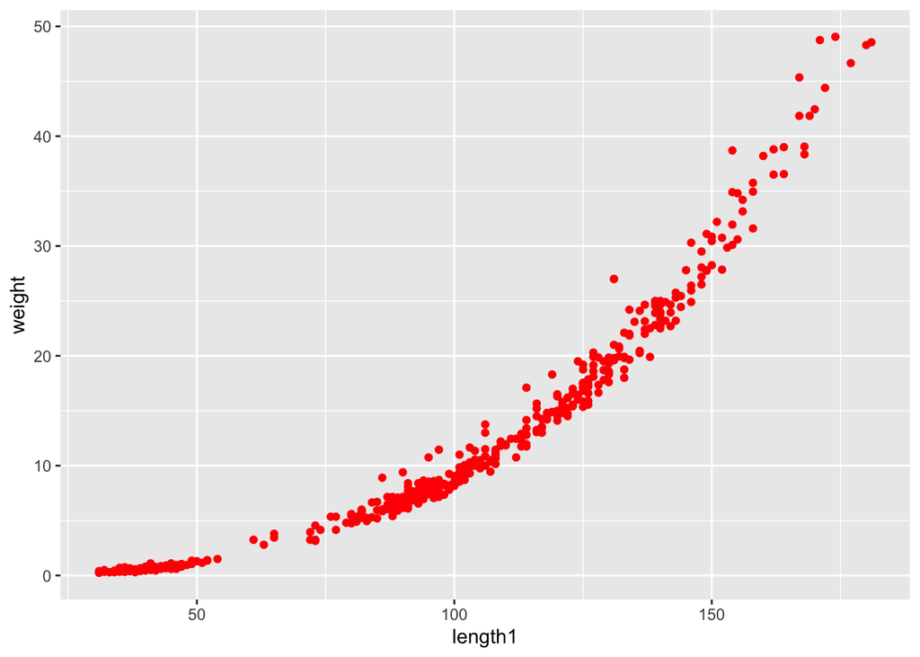

```r
# Plot it!
ggplot(data = cutthroat_1990, aes(x = length1, y = weight)) +
  geom_point(color = "red")
```

## `dplyr::mutate()`

Use `dplyr::mutate()` to add or transform columns, while keeping existing columns in your data frame.

Let’s say we want to add a column that contains weight (currently in grams) into kilograms. We’ll call the new column `weight_kg`.

```r
verts_wt_kg <- verts %>%
  clean_names() %>%
  mutate(weight_kg = weight / 1000)
```

## `dplyr::group_by() %>% summarize()`

Use `group_by() %>% summarize()` to find and report summary statistics by group.

```r
verts_clean %>%
  drop_na(species) %>%
  group_by(species) %>%
  summarize(mean_length = mean(length1, na.rm = TRUE),
            sd_length = sd(length1, na.rm = TRUE))
```

```
## # A tibble: 3 × 3
##   species mean_length sd_length
##   <chr>         <dbl>     <dbl>
## 1 DITE           57.0     20.9
## 2 ONCL           83.5     35.4
## 3 RHOL           35.9      5.20
```

```r
# We can also group by multiple variables!
verts_clean %>%
  drop_na(species) %>%
  group_by(species, section) %>%
  summarize(mean_length = mean(length1, na.rm = TRUE),
            sd_length = sd(length1, na.rm = TRUE))
```

```
## # A tibble: 6 × 4
## # Groups:   species [3]
##   species section mean_length sd_length
##   <chr>   <chr>         <dbl>     <dbl>
## 1 DITE    CC             60.5     20.8
## 2 DITE    OG             54.0     20.5
## 3 ONCL    CC             85.3     36.0
## 4 ONCL    OG             81.4     34.5
## 5 RHOL    CC             37        3.54
## 6 RHOL    OG             34.3      7.12
```

## Wrap-up

Congratulations! In Lab 1, you have:

- Made an R Project (self-contained working directory)
- Added data
- Created a new R Markdown document
- Read in the data
- Did some basic exploring
- Some data wrangling basics (select, filter, mutate, group_by + summarize)
- Learned a few base operations (mean, sd, max, min, n, na.rm = TRUE)
- Used the pipe operator for sequences of steps
- Made a ggplot2 graph!

Save / knit, close your project, and reopen (by double clicking the .Rproj file), and ensure that you can re-run everything.

YAY reproducibility!

## END LAB 1